# Agrupamento de células e expressão diferencial em transcriptômica de célula única

Minicurso da 70ª RBras · Encontro 2 de 2

Benilton S Carvalho (IMECC/UNICAMP)

## Retomada

Encontro 1

B01Entrada de dados

B02aObjeto Seurat e doublets

B02bQualidade e filtragem

B03Normalização e escala

B04PCA

B05SCTransform

B06UMAP

Encontro 2

B07Agrupamento e resolução

B08Genes marcadores

B09Expressão diferencial

B10Anotação automatizada

B11Anotação manual

B12Enriquecimento GO

## Organização do encontro 2

| Bloco | Nome | Início | Teoria | Prática |
| --- | --- | --- | --- | --- |
| R00 | Retomada e configuração | 08:00 | 4 min | 8 min |
| B07 | Agrupamento e resolução | 08:12 | 8 min | 12 min |
| B08 | Genes marcadores | 08:32 | 7 min | 12 min |
| B09 | Expressão diferencial | 08:51 | 6 min | 9 min |
| B10 | Anotação automatizada | 09:06 | 5 min | 9 min |
| B11 | Anotação manual | 09:20 | 4 min | 7 min |
| B12 | Enriquecimento GO | 09:31 | 5 min | 6 min |

# Retomada e configuração

BLOCO R00

Teoria 4 min · Prática 8 min · Início 08:00

## Etapas do bloco R00

1`source()`

2`load()`

3`baixar()`

## Retomada e configuração 1/2

- Nesta seção, configuraremos o ambiente de computação necessário
- A configuração envolve usar Shell e R dentro deste notebook.
- R é uma linguagem de programação e ambiente de software para análise de dados, estatísticas e gráficos.
- R é de código aberto

## Retomada e configuração 2/2

- Um pacote em R é uma coleção de funções, dados e documentação agrupados.
- Antes de usar um pacote, ele deve ser instalado no seu ambiente.
- Uma vez instalado, o pacote precisa ser carregado em cada sessão em que você deseja usá-lo.
- O objeto do encontro 1 é carregado do ponto de resgate CP3.

## Prática: bloco R00

8minutos

1. Abra a seção **Bloco R00** do notebook.
2. Execute as 3 células de código, na ordem.

VERIFICACAO R00: 20271x3541

## Onde paramos no encontro 1

[figure not shown]

# Agrupamento e resolução

BLOCO B07

Teoria 8 min · Prática 12 min · Início 08:12

## Etapas do bloco B07

1`FindNeighbors()`

2`FindClusters()`

3`DimPlot()`

4`clustree()`

## Agrupamento e resolução 1/4

- Clustering é um método usado em análise de dados para agrupar objetos com base em suas similaridades.
- No contexto do scRNA-seq, o clustering ajuda a identificar populações celulares distintas agrupando células com perfis de expressão genética semelhantes.
- Agora, vamos realizar o clustering formal nesses dados.

## Agrupamento e resolução 2/4

- Embora existam vários algoritmos de clustering disponíveis, usaremos uma abordagem de grafo de vizinho mais próximo
- Este método funciona construindo um grafo onde cada ponto de dados (célula) é conectado aos seus vizinhos mais próximos.
- Em seguida, o algoritmo de Louvain é usado para encontrar grupos densamente conectados, indicando clusters.

## Agrupamento e resolução 4/4

- Quase todos os algoritmos de clustering têm algum tipo de parâmetro livre que controla quantos clusters são identificados.
- No algoritmo de Louvain, temos a *resolução* que, mantendo todos os outros parâmetros constantes, controla o número de clusters.
- Valores baixos (altos) dão números baixos (altos) de clusters.

## Do PCA ao grafo de vizinhos

[figure not shown]

Exemplo com 50 pontos. O Louvain não usa as coordenadas: ele trabalha sobre o grafo SNN, em que a espessura da aresta é o peso.

## Grafos kNN e SNN no Seurat

- FindNeighbors liga cada célula às k = 20 mais próximas nos 20 primeiros PCs.
- No grafo SNN, o peso é a fração de vizinhos em comum (índice de Jaccard).
- Arestas com peso menor que 1/15 são removidas.
- Nesta amostra, o grafo tem 3.541 nós e 117.724 arestas.

## O que o Louvain maximiza

- $Q = \frac{1}{2m}\sum_{i,j}\left[A_{ij} - \gamma\frac{k_i k_j}{2m}\right]\delta(c_i, c_j)$
- $A_{ij}$: peso da aresta; $k_i$: soma dos pesos da célula $i$; $m$: peso total.
- Q compara o peso dentro dos grupos com o esperado ao acaso.
- A resolução γ pesa o termo do acaso: γ maior gera mais grupos.

## Louvain em duas fases

[figure not shown]

As duas fases se repetem até Q parar de crescer. O Seurat faz 10 inícios aleatórios e guarda a partição de maior Q.

## Efeito da resolução no exemplo

[figure not shown]

Mesmo grafo, três valores de γ: 3, 4 e 7 grupos. A resolução não muda o grafo; muda só o critério de partição.

## Resolução nesta amostra

- γ = 0,01: 3 grupos; γ = 0,8 (padrão): 17; γ = 10: 59.
- Q não compara resoluções: a própria fórmula muda com γ.
- algorithm = 4 usa o Leiden, que garante grupos conexos.
- Blondel et al., 2008 (Louvain); Traag et al., 2019 (Leiden).

## Prática: bloco B07

12minutos

1. Abra a seção **Bloco B07** do notebook.
2. Execute as 12 células de código, na ordem.

VERIFICACAO B07: 3

## Grupos no UMAP com resolução padrão

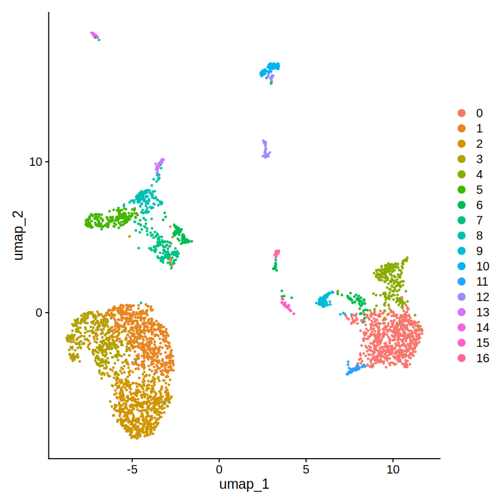

As cores são os 17 grupos do Louvain (γ = 0,8) no grafo SNN dos 20 primeiros PCs. O UMAP só posiciona as células no plano.

Saída da célula 144 do Módulo 04 · `DimPlot()`

## Grupos no UMAP com resolução 0,01

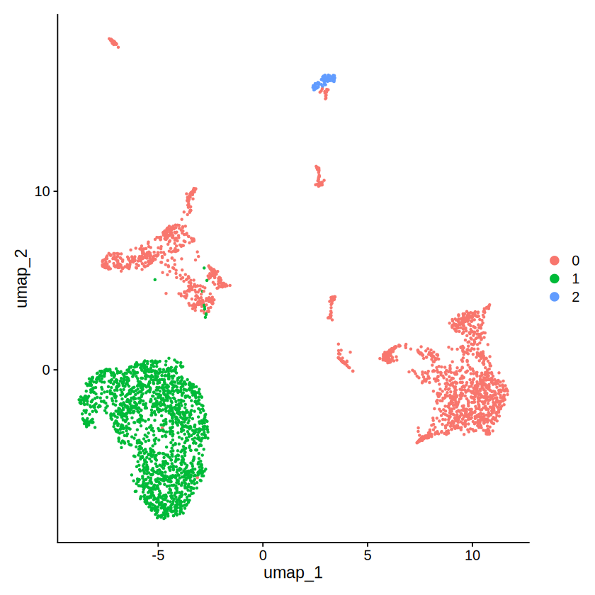

Com γ = 0,01, o Louvain forma 3 grupos. Um deles reúne só as 71 células ciliadas.

Saída da célula 147 do Módulo 04 · `DimPlot()`

## Grupos no UMAP com resolução 10

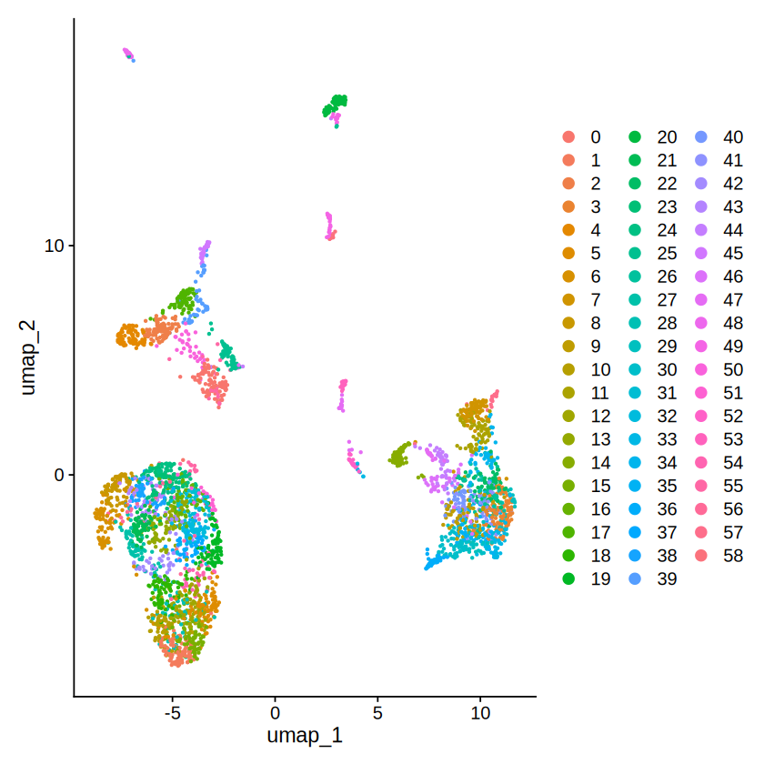

Com γ = 10, o Louvain forma 59 grupos: populações homogêneas aparecem fragmentadas.

Saída da célula 149 do Módulo 04 · `DimPlot()`

## UMAP mostra, Louvain agrupa

- As cores vêm do Louvain, aplicado ao grafo SNN dos 20 primeiros PCs.
- O UMAP usa 15 PCs só para desenhar as células no plano.
- Grupos vizinhos no UMAP podem estar distantes no grafo.
- Um grupo partido no UMAP não indica erro do agrupamento.

## Outra via: hclust e cutree

- hclust() com ligação de Ward nos 20 primeiros PCs.
- cutree(hc, k) corta a árvore em k grupos.
- Silhueta: compara a distância ao próprio grupo e ao vizinho.
- ARI: concordância entre duas partições; 1 é total.

## Árvore do hclust nesta amostra

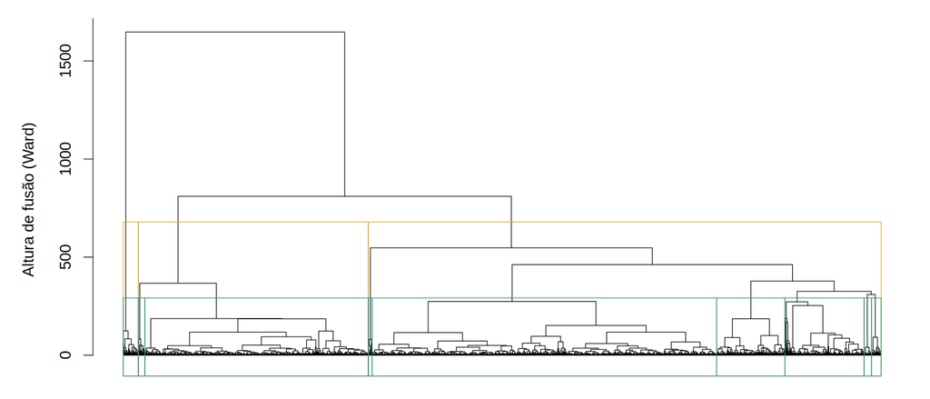

Cortes em k = 3 (ouro) e k = 9 (verde). O maior salto de altura, no topo, separa as 71 células ciliadas do resto.

## Silhueta média por número de grupos

[figure not shown]

Fora o k = 2, a silhueta fica perto de 0,40 entre 5 e 9 grupos nos dois métodos. Com γ = 0,2 (11 grupos), usado no notebook, cai para 0,27.

## cutree e Louvain com 3 grupos

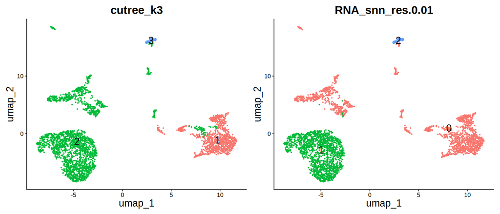

Os dois isolam as 71 células ciliadas, mas dividem o resto de formas diferentes: ARI = 0,34.

## cutree (k = 9) e Louvain (γ = 0,1)

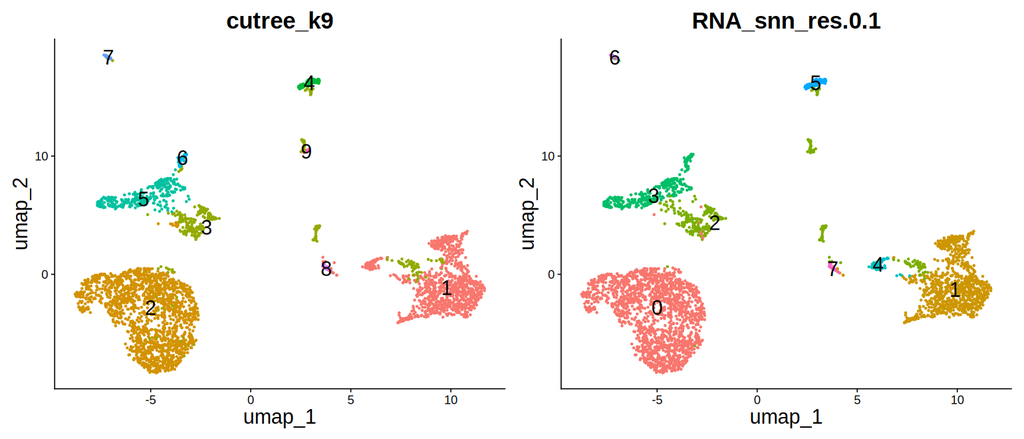

Com 9 grupos no cutree e 8 no Louvain, as partições quase coincidem: ARI = 0,92. Métodos diferentes que concordam dão confiança aos grupos.

## Como escolher o número de grupos

- Não há número correto: ele depende da pergunta biológica.
- Combine silhueta, estabilidade entre resoluções (clustree) e marcadores.
- Grupos sem marcadores próprios devem ser unidos ao vizinho.
- A silhueta sozinha engana: aqui ela prefere k = 2.

# Genes marcadores

BLOCO B08

Teoria 7 min · Prática 12 min · Início 08:32

## Etapas do bloco B08

1`FindMarkers()`

2`FeaturePlot()`

3`VlnPlot()`

4`ggplot()`

5`FindAllMarkers()`

6`DoHeatmap()`

## Por que procurar marcadores

- Cada tipo celular expressa programas transcricionais próprios.
- Esses genes são a impressão digital que traduz clusters em identidades biológicas.

## O que é um gene marcador

- Gene enriquecido em um cluster em relação às demais células.
- Marcador positivo: superexpresso.
- Marcador negativo: ausência consistente no grupo.

## Como o FindMarkers funciona

- Compara o grupo ident.1 com o grupo de referência ident.2.
- Sem ident.2, a referência são todas as demais células do objeto.
- Teste padrão: soma de postos de Wilcoxon, sem pressupor normalidade.
- Outros testes disponíveis: regressão logística, MAST e binomial negativo.

## Lendo a tabela de marcadores

- avg_log2FC: diferença média de expressão em log2; positivo indica maior em ident.1.
- pct.1 e pct.2: fração de células com o gene em cada grupo.
- p_val_adj: p-valor corrigido por Bonferroni para múltiplos testes.
- only.pos = TRUE mantém apenas os genes superexpressos no grupo.

## Marcadores de todos os grupos

- FindAllMarkers repete o FindMarkers para cada cluster contra todas as demais células.
- logfc.threshold = 0.25 testa só genes com variação mínima de cerca de 19%.
- Confira no FeaturePlot e no VlnPlot: expressão restrita ao cluster-alvo.

## Um contra todos e dois a dois

[figure not shown]

O FindAllMarkers não faz comparações dois a dois: ele repete o “um contra todos” para cada grupo. Pares exigem FindMarkers com ident.2.

## Por que o FindAllMarkers importa

- Dá, de uma vez, a assinatura de cada grupo contra o resto da amostra.
- Alimenta o DoHeatmap e a anotação manual dos grupos.
- Nesta amostra: 23.516 marcadores positivos nos 11 grupos (γ = 0,2).
- Para separar dois grupos parecidos, use FindMarkers com ident.2.

## O que os testes recebem

- Genes nas linhas, células nas colunas; cada valor conta UMIs.
- Wilcoxon, LR e MAST usam a camada data: $\log(1 + 10^4 \cdot y_{gc}/m_c)$.
- O binomial negativo usa a camada counts: contagens de UMIs.
- Um teste por gene; p_val_adj = p-valor × 20.271 genes.

## Teste de Wilcoxon (padrão)

- Ordena a expressão normalizada do gene nas células dos dois grupos.
- $W = \sum_{c \in G_1} r_c$, soma dos postos das células do grupo 1.
- H0: mesma distribuição nos dois grupos; não supõe normalidade.
- O Seurat usa o pacote presto, rápido para milhares de genes.

## Regressão logística (LR)

- Inverte o problema: a expressão do gene prevê o grupo da célula.
- $\mathrm{logit}\, P(c \in G_1) = \beta_0 + \beta_1 x_{gc}$
- Testa $\beta_1 = 0$ pela razão de verossimilhanças.
- Aceita covariáveis em latent.vars, como lote.

## MAST: modelo com barreira

- Detecção: $\mathrm{logit}\, P(x_{gc} > 0) = \alpha_0 + \alpha_1 g_c$
- Nível, se detectado: $x_{gc} \sim N(\beta_0 + \beta_1 g_c, \sigma^2)$
- Testa $\alpha_1 = \beta_1 = 0$ pela razão de verossimilhanças (2 g.l.).
- Finak et al., Genome Biology, 2015.

## Binomial negativo

- Usa as contagens brutas de UMIs, não a expressão normalizada.
- $y_{gc} \sim \mathrm{NB}(\mu_{gc}, \theta_g)$, com $\log \mu_{gc} = \beta_0 + \beta_1 g_c$
- Testa $\beta_1 = 0$ pelo teste de Wald; aceita latent.vars.
- Indicado só para dados de UMI; mais lento que o Wilcoxon.

## Os testes em cinco genes

| Gene | Wilcoxon | t de Welch | Binomial negativo |
| --- | --- | --- | --- |
| MCEMP1 | 1,0 × 10⁻²⁰⁸ | 2,5 × 10⁻³¹⁸ | 5,6 × 10⁻¹⁸⁰ |
| IFITM1 | 3,5 × 10⁻¹³⁶ | 1,6 × 10⁻¹⁷² | 1,1 × 10⁻²²⁵ |
| CXCL11 | 9,3 × 10⁻¹¹⁶ | 3,8 × 10⁻¹⁴⁰ | 1,5 × 10⁻²¹⁵ |
| APOE | 7,4 × 10⁻¹¹⁵ | 3,6 × 10⁻¹²⁷ | 3,8 × 10⁻¹⁹⁸ |
| HP | 3,0 × 10⁻¹²⁵ | 2,1 × 10⁻¹⁰⁶ | 5,3 × 10⁻¹²⁰ |

Grupo 2 contra 0. Os testes concordam, mas a ordem dos genes muda. LR e MAST exigem os pacotes lmtest e MAST, ausentes no ambiente do curso.

## Prática: bloco B08

12minutos

1. Abra a seção **Bloco B08** do notebook.
2. Execute as 12 células de código, na ordem.

VERIFICACAO B08: 11/10246

## Expressão de C1QA no UMAP

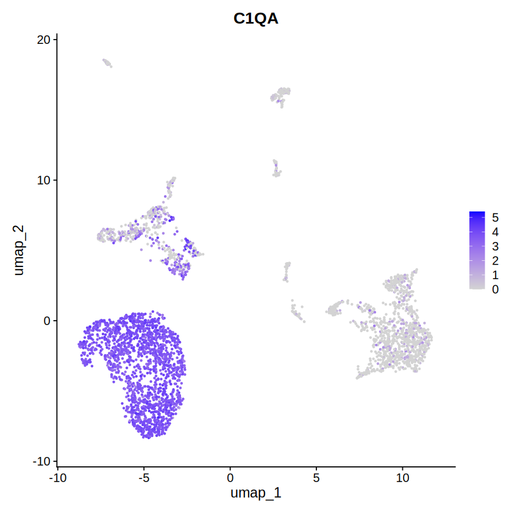

Saída da célula 159 do Módulo 04 · `FeaturePlot()`

## Expressão de RBP7 no UMAP

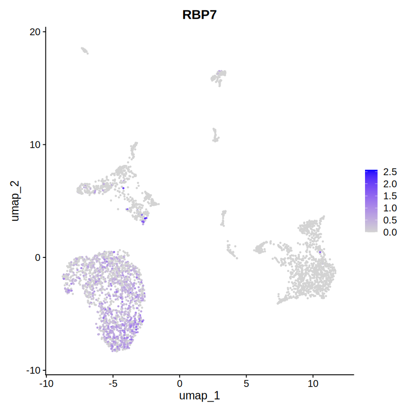

Saída da célula 162 do Módulo 04 · `FeaturePlot()`

## Expressão de C1QC no UMAP

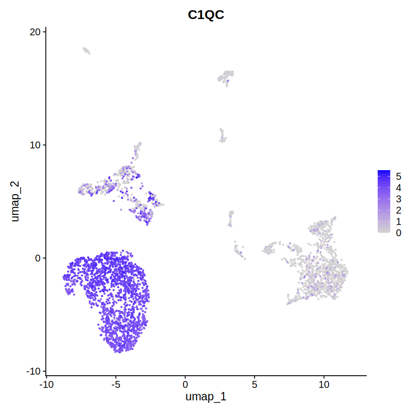

Saída da célula 163 do Módulo 04 · `FeaturePlot()`

# Expressão diferencial

BLOCO B09

Teoria 6 min · Prática 9 min · Início 08:51

## Etapas do bloco B09

1`FindMarkers()`

2`FeaturePlot()`

3`FindAllMarkers()`

4`DoHeatmap()`

## O que muda no bloco B09

[figure not shown]

As etapas dos blocos B08 e B09 são quase iguais porque ambos usam FindMarkers. Muda a referência: no B09, o grupo 2 é comparado só com o grupo 0.

## Por que comparar o grupo 2 com o 0

- Na resolução 0,2, os grupos 0 e 2 são macrófagos: 1.043 e 584 células.
- Genes do grupo 0, como APOE e CCL18, também aparecem no 2.
- O par destaca MCEMP1 e HP no grupo 2; IFITM1 e CXCL11 no 0.
- IFITM1 e CXCL11 são induzidos por interferon: estados distintos de ativação.

## Marcador versus expressão diferencial

- Um contra todos: o que torna este cluster exclusivo na amostra?
- Dois grupos entre si: o que diferencia a população A da B?
- Um contra todos pode mascarar genes compartilhados por clusters semelhantes.
- A comparação de pares não garante que o gene seja exclusivo no tecido.

## Cuidados na interpretação

- Use sempre o p_val_adj; a correção de Bonferroni é conservadora.
- Julgue a relevância pelo tamanho de efeito: avg_log2FC e contraste entre pct.1 e pct.2.
- Células não são réplicas independentes: há pseudorreplicação e p-valores inflados.
- Com várias amostras, prefira pseudobulk com DESeq2 ou edgeR.

## Do resultado à biologia

- O DoHeatmap mostra os 5 principais marcadores de cada cluster, célula a célula.
- Blocos em escada na diagonal indicam assinaturas próprias de cada grupo.
- Cinco genes juntos formam uma assinatura mais robusta que um gene isolado.

## FDR: taxa de falsas descobertas

- R genes significativos, V falsos: $\mathrm{FDR} = E[V/\max(R,1)]$.
- Bonferroni limita a chance de algum falso positivo: $p \le \alpha/G$.
- Benjamini e Hochberg: rejeite os $k$ menores, $k = \max\{i: p_{(i)} \le iq/G\}$.
- Em R: p.adjust(p, method = “BH”, n = G).

## Bonferroni e FDR nesta amostra

- G = 20.271 genes: Bonferroni a 5% exige $p \le 2{,}5 \times 10^{-6}$.
- Grupo 2 contra 0: 1.793 genes por Bonferroni; 4.297 com FDR de 5%.
- O p_val_adj do Seurat é Bonferroni; o FDR exige p.adjust.
- Com centenas de células, p-valores despencam: olhe o avg_log2FC.

## Prática: bloco B09

9minutos

1. Abra a seção **Bloco B09** do notebook.
2. Execute as 7 células de código, na ordem.

VERIFICACAO B09: 23516

## Expressão de MCEMP1 no UMAP

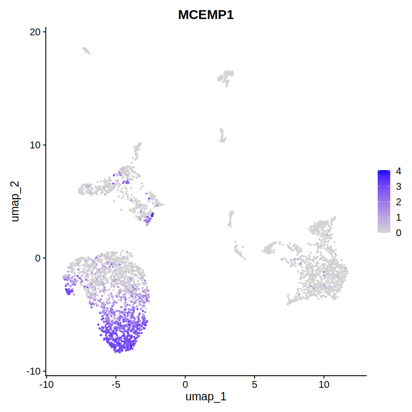

Saída da célula 173 do Módulo 04 · `FeaturePlot()`

## Expressão de CXCL11 no UMAP

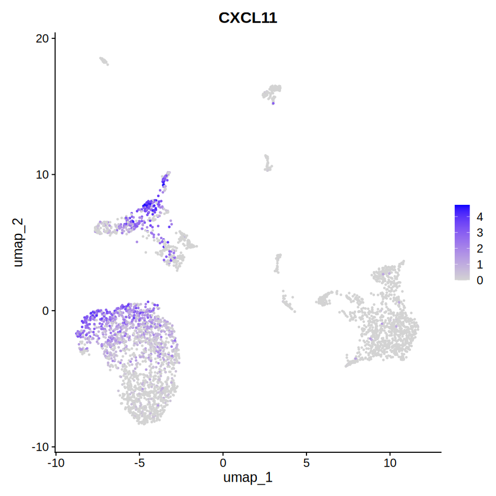

Saída da célula 174 do Módulo 04 · `FeaturePlot()`

## Cinco principais marcadores por grupo

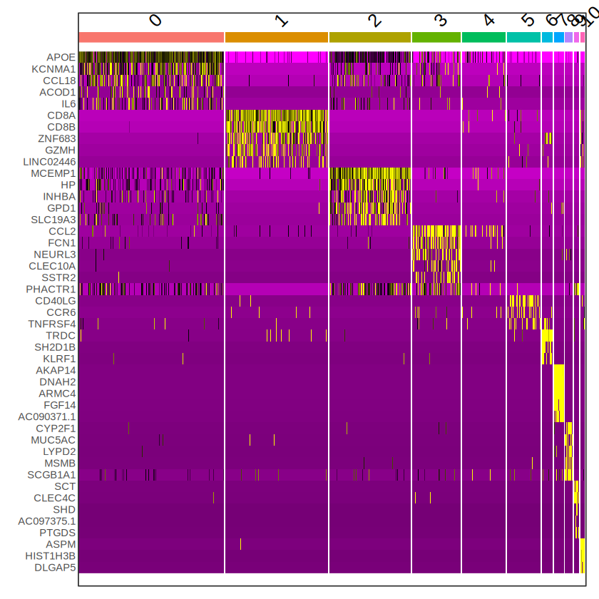

Cada bloco na diagonal é a assinatura de um grupo. Genes do grupo 0, como APOE e CCL18, também aparecem no 2: são dois tipos de macrófago, comparados no B09.

Saída da célula 175 do Módulo 04 · `FindAllMarkers()`

# Anotação automatizada

BLOCO B10

Teoria 5 min · Prática 9 min · Início 09:06

## Etapas do bloco B10

1`readRDS()`

2`baixar()`

3`as.SingleCellExperiment()`

4`SingleR()`

5`plotScoreHeatmap()`

6`pheatmap()`

## Anotação de Tipos Celulares 1/2

- Interpretar os resultados da análise de dados de células individuais costuma ser a parte mais desafiadora do processo.
- Podemos anotar os tipos celulares comparando os perfis de expressão dos nossos dados com um conjunto de dados de referência.
- Essa abordagem nos permite fornecer interpretações mais significativas dos agrupamentos.

## Anotação de Tipos Celulares 2/2

- As melhores práticas recomendam uma abordagem híbrida, na qual a anotação automatizada é ponto de partida, seguida pela validação manual
- O uso de bancos de dados como o PanglaoDB e o CELLxGENE também pode ser uma alternativa útil nesta etapa.

## Anotação automatizada

- O pacote celldex oferece diversos conjuntos de dados de referência bem curados e anotados.
- Em nosso caso, usaremos os conjuntos de dados de referência Blueprint e ENCODE
- A função `SingleR()` pega nosso conjunto de dados, o conjunto de referência e os rótulos do conjunto de referência.

## Prática: bloco B10

9minutos

1. Abra a seção **Bloco B10** do notebook.
2. Execute as 5 células de código, na ordem.

VERIFICACAO B10: 14

## Pontuações do SingleR por célula

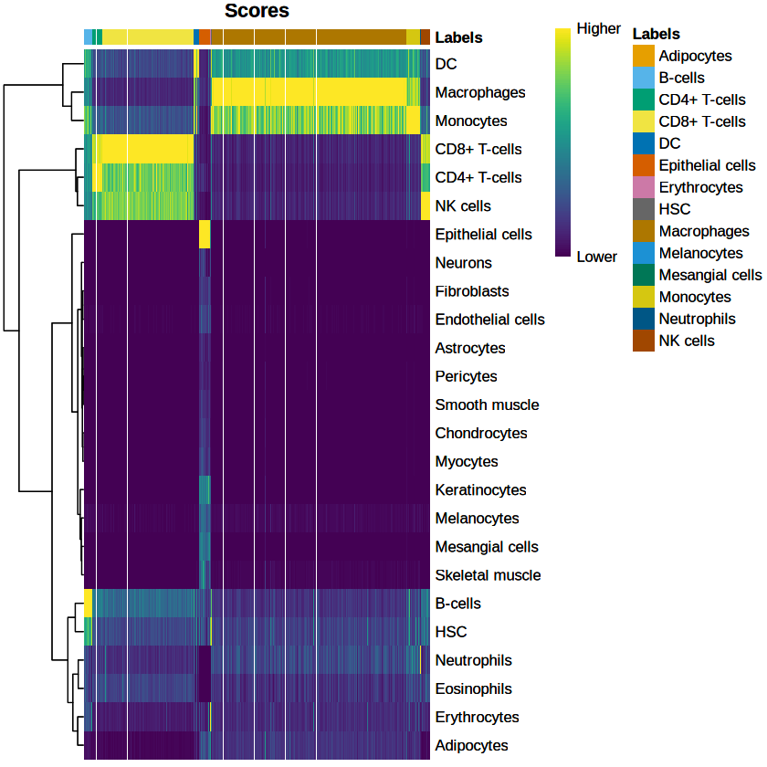

Saída da célula 183 do Módulo 04 · `plotScoreHeatmap()`

# Anotação manual

BLOCO B11

Teoria 4 min · Prática 7 min · Início 09:20

## Etapas do bloco B11

1`DimPlot()`

2`DotPlot()`

## Anotação manual 1/2

- Esta abordagem baseia-se em um conjunto de marcadores genéticos conhecidos associados a um tipo celular.
- Nesta etapa, um conjunto robusto de genes marcadores e conhecimento prévio são ideais para um bom resultado.
- No entanto, esta etapa é crítica devido ao risco de anotações imprecisas, detecção incompleta de marcadores e subjetividade.

## Anotação manual 2/2

- Anotação baseada em genes marcadores das populações celulares que esperamos encontrar
- Identificação dos genes marcadores em cada cluster para inferir qual tipo celular representa essa população.
- Vamos criar um painel de marcadores conhecidos para populações celulares que esperamos encontrar em nosso conjunto de dados.

## Anotação manual em quatro passos

- 1. Liste marcadores canônicos dos tipos esperados no tecido.
- 2. Meça, em cada grupo, a expressão média e a fração de células (DotPlot).
- 3. Dê a cada grupo o tipo cujos marcadores se destacam só nele.
- 4. Confira com FindAllMarkers e SingleR; divida ou una grupos ambíguos.

## Como ler o DotPlot

- Tamanho do ponto: fração de células do grupo que expressam o gene.
- Cor: expressão média padronizada entre os grupos.
- Bom marcador: ponto grande e escuro em poucos grupos.
- O notebook retira os pontos com menos de 5% de células.

## Fontes de marcadores canônicos

- Literatura do tecido estudado: aqui, Liao et al., 2020.
- Bancos de marcadores: PanglaoDB e CellMarker.
- Atlas de referência: CELLxGENE e Human Cell Atlas.
- Um único gene raramente basta: use painéis de três ou mais genes.

## Prática: bloco B11

7minutos

1. Abra a seção **Bloco B11** do notebook.
2. Execute as 5 células de código, na ordem.

VERIFICACAO B11: 7

## Grupos rotulados no UMAP

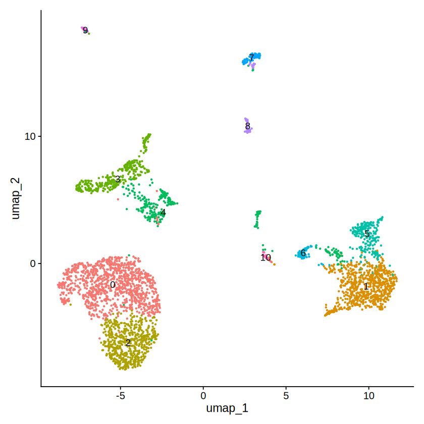

Saída da célula 187 do Módulo 04 · `DimPlot()`

## Marcadores de tipos celulares por grupo

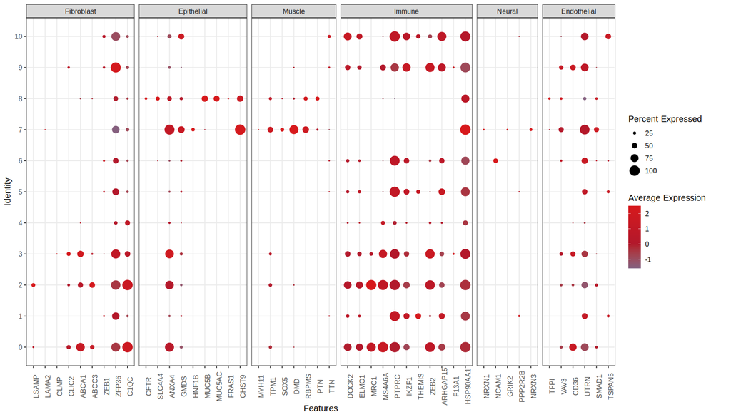

Saída da célula 189 do Módulo 04 · `DotPlot()`

## Marcadores de células imunes por grupo

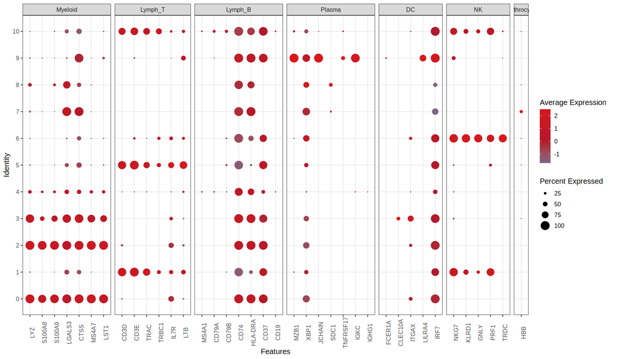

Linfócitos T nos grupos 1, 5 e 10; NK no 6; mieloides em 0, 2 e 3. LILRA4 e IRF7 no grupo 9 indicam DC plasmocitoides.

Saída da célula 191 do Módulo 04 · `DotPlot()`

## Anotação proposta 1/2

| Grupo | Células | Marcadores | SingleR | Tipo proposto |
| --- | --- | --- | --- | --- |
| 0 | 1.043 | APOE, CCL18, IL6 | Macrófagos | Macrófagos |
| 1 | 738 | CD8A, CD8B, GZMH | T CD8 | Linfócitos T CD8 |
| 2 | 584 | MCEMP1, HP, FABP4 | Macrófagos | Macrófagos |
| 3 | 350 | CCL2, FCN1, CLEC10A | Macrófagos, monócitos, DC | Monócitos e DC |
| 4 | 314 | CSF3R, FCGR3B | B, monócitos | Neutrófilos? |
| 5 | 242 | CD40LG, CD28, IL7R | T CD4 e CD8 | Linfócitos T CD4 |

## Anotação proposta 2/2

| Grupo | Células | Marcadores | SingleR | Tipo proposto |
| --- | --- | --- | --- | --- |
| 6 | 76 | TRDC, KLRF1, NCR1 | NK | Células NK |
| 7 | 71 | DNAH2, FOXJ1, TPPP3 | Epiteliais | Epitélio ciliado |
| 8 | 55 | MUC5AC, SCGB1A1 | Epiteliais | Epitélio secretor |
| 9 | 37 | CLEC4C, LILRA4, PTGDS | B | DC plasmocitoides |
| 10 | 31 | ASPM, HIST1H3B, CD3E | T CD8 | T em proliferação |

O SingleR chama o grupo 9 de célula B porque a referência não tem DC plasmocitoide entre os rótulos principais. O grupo 4 segue ambíguo.

# Enriquecimento GO

BLOCO B12

Teoria 5 min · Prática 6 min · Início 09:31

## Análises de enriquecimento GO

- A análise de enriquecimento é uma ferramenta para extrair informações biologicamente relevantes de dados de células únicas
- Essa análise pode revelar associações inesperadas entre conjuntos de genes e termos da Ontologia Genética (GO)
- A Análise de Enriquecimento GO é um método usado para identificar termos GO super-representados em um conjunto de genes.

## Classificação do GO

- Processos Biológicos (Biological Processes - BP): Os objetivos biológicos para os quais o gene contribui
- Funções Moleculares (Molecular Functions - MF): As atividades moleculares realizadas pelo produto do gene
- Componentes Celulares (Cellular Components - CC): O local dentro da célula onde o produto do gene é ativo

## GO em outros organismos

- É importante ressaltar que a análise de enriquecimento de vias não se restringe a modelos humanos ou animais.
- Do ponto de vista técnico, qualquer identificador compatível com um objeto `OrgDb` pode ser usado em análises baseadas em GO
- Os usuários podem recuperar anotações específicas do organismo por meio de recursos online como o AnnotationHub

## Prática: bloco B12

6minutos

1. Abra a seção **Bloco B12** do notebook.
2. Execute as 8 células de código, na ordem.

VERIFICACAO B12: 649

## Materiais

Rojas-Hidalgo A, Arias-Carrasco R, Silva JK, et al. The Single Cell Notebooks for inclusive and accessible training in single-cell and spatial omics. *Nature Genetics* 58, 1189-1194 (2026).

DOI: 10.1038/s41588-026-02584-0

Notebooks: github.com/integrativebioinformatics/scNotebooks

## Origem dos dados

Liao M, Liu Y, Yuan J, et al. Single-cell landscape of bronchoalveolar immune cells in patients with COVID-19. *Nature Medicine* 26, 842-844 (2020). GEO: GSE145926, amostra GSM4339769.

DOI: 10.1038/s41591-020-0901-9